# RTqPCR_CryptoMobius

Liz Hughes

12/01/23

# Experimental Design

This experiment was set up to examine the expression of Gat201 and some Gat201 target genes in different strains grown under the same conditions.

RTqPCR of WT, Gat201 deletion, Complemented clones C26 and C30.

This experiment was set up to show the complementation of native Gat201 into SH4 in the Madahani GAT201 deletion strain (C26 and C30).

Strains: H99, KN99-alpha, Madhani Gat201 deletion mutant, and 2 Gat201 complemented strains (into Madhani-Gat201 deletion strain) C26 and C30.

Culture conditions: Set up overnight cultures from a single colony in YPD at 30 degrees, 150rpm, 3 biological replicates. Cultures were set up in 20 ml RPMI at an OD of 0.1 from the ON culture. Cell were washed with RPMI prior to testing the OD and setting up cultures in RPMI. Cultures were incubated at 37 degrees, 150rpm for 7 hours.

Sample collection: 19 ml Samples were collected at 7 hours. Samples were fixed in methanol on dry ice for 3-5 mins. My Cryptococcus RNA extraction protocol was followed to isolate RNA from samples.

Replicates: 3 biological replicates were collected for each sample. 3 technical replicates +RT and 1 -RT

Test Primers: Plate 1: Gat201 CNAG_01551 (set 1) PDR802 CNAG_03894 (Set 5) TSA3 CNAG_06917 (Set 2)

Plate 2: BLP1 CNAG_06346 (Set 4) Meu1 CNAG_00165 (Set 4) MEP1 CNAG_04735 (Set 1)

Reference gene primers for both plates: SRP14 CNAG_04994 (Set 5) ACT1 CNAG_00483 (Set 5) GPD CNAG_00121 (Set 5)

# Load Packages

```r
library(tidyverse)
library(tidyr)
library(cowplot)
library(tidyqpcr)
library(dplyr)
library(rlang)
library(markdown)
library(ggplot2)
library(here)

# set default theme for plots

theme_set(theme_bw(base_size = 11) %+replace%
  theme(
    strip.background = element_blank(),
    panel.grid = element_blank()
  ))
```

# Plate 1

## Create Plateplan 1

### List target_ids of primer sets

```r
colkey <- create_colkey_6_in_24(target_id = c("Gat201", "TSA3", "PDR802", "SRP14", "ACT1", "GPD"))

print(colkey)
```

```
## # A tibble: 24 × 4
##    well_col prep_type tech_rep target_id
##    <fct>    <fct>     <fct>    <chr>
##  1 1        +RT       1        Gat201
##  2 2        +RT       1        TSA3
##  3 3        +RT       1        PDR802
##  4 4        +RT       1        SRP14
##  5 5        +RT       1        ACT1
##  6 6        +RT       1        GPD
##  7 7        +RT       2        Gat201
##  8 8        +RT       2        TSA3
##  9 9        +RT       2        PDR802
## 10 10       +RT       2        SRP14
## # … with 14 more rows
```

## Set up experimental samples plate 1

### List sample name, BioRep (3) and TechRep (3)

```r
Samples <- c("H99-1", "H99-2", "H99-3", "KN99alpha-1", "KN99alpha-2", "KN99alpha-3", "deltaGat201-1", "deltaGat201-2", "deltaGat201-3", "C26-1", "C26-2", "C26-3", "C30-1", "C30-2", "C30-3")

TechReps <- c("1", "2", "3")

rowkey <- tibble(well_row=LETTERS[1:15],
                 sample_id= Samples)

print(rowkey)
```

```
## # A tibble: 15 × 2
##    well_row sample_id
##    <chr>    <chr>
##  1 A        H99-1
##  2 B        H99-2
##  3 C        H99-3
##  4 D        KN99alpha-1
##  5 E        KN99alpha-2
##  6 F        KN99alpha-3
##  7 G        deltaGat201-1
##  8 H        deltaGat201-2
##  9 I        deltaGat201-3
## 10 J        C26-1
## 11 K        C26-2
## 12 L        C26-3
## 13 M        C30-1
## 14 N        C30-2
## 15 O        C30-3
```

## Plateplan1

```r
plate1 <- label_plate_rowcol(
  plate = create_blank_plate(well_row = LETTERS[1:15], well_col = 1:24),
  rowkey = rowkey,
  colkey = colkey
)
print(plate1)
```

```
## # A tibble: 360 × 7
##    well  well_row well_col prep_type tech_rep target_id sample_id
##    <chr> <fct>    <fct>    <fct>     <fct>    <chr>     <chr>
##  1 A1    A        1        +RT       1        Gat201    H99-1
##  2 A2    A        2        +RT       1        TSA3      H99-1
##  3 A3    A        3        +RT       1        PDR802    H99-1
##  4 A4    A        4        +RT       1        SRP14     H99-1
##  5 A5    A        5        +RT       1        ACT1      H99-1
##  6 A6    A        6        +RT       1        GPD       H99-1
##  7 A7    A        7        +RT       2        Gat201    H99-1
##  8 A8    A        8        +RT       2        TSA3      H99-1
##  9 A9    A        9        +RT       2        PDR802    H99-1
## 10 A10   A        10       +RT       2        SRP14     H99-1
## # … with 350 more rows
```

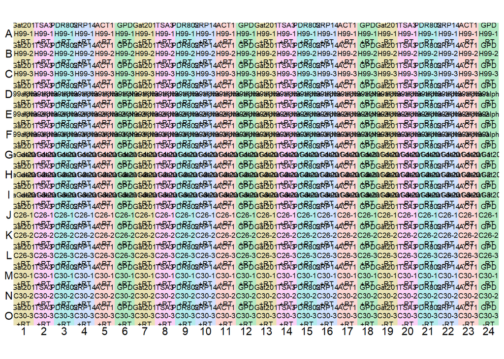

```r
display_plate_qpcr(plate1)
```

## Load data for plate 1

```r
plate1 <-  read_tsv("../data/EH_20230112_CryptoMob_plate1_Ct.txt",
            skip=1) %>%
          mutate(well=Pos,cq=Cp) %>%
          right_join(plate1)

plate1
```

```
## # A tibble: 360 × 16
##    Include Color Pos   Name        Cp Conce…¹ Stand…² Status well     cq well_…³
##    <lgl>   <dbl> <chr> <chr>    <dbl> <lgl>     <dbl> <lgl>  <chr> <dbl> <fct>
##  1 TRUE      255 A1    Sample 1  18.8 NA            0 NA     A1     18.8 A
##  2 TRUE      255 A2    Sample 2  21.0 NA            0 NA     A2     21.0 A
##  3 TRUE      255 A3    Sample 3  14.0 NA            0 NA     A3     14.0 A
##  4 TRUE      255 A4    Sample 4  22.4 NA            0 NA     A4     22.4 A
##  5 TRUE      255 A5    Sample 5  17.4 NA            0 NA     A5     17.4 A
##  6 TRUE      255 A6    Sample 6  23.4 NA            0 NA     A6     23.4 A
##  7 TRUE      255 A7    Sample 7  18.5 NA            0 NA     A7     18.5 A
##  8 TRUE      255 A8    Sample 8  20.8 NA            0 NA     A8     20.8 A
##  9 TRUE      255 A9    Sample 9  14.0 NA            0 NA     A9     14.0 A
## 10 TRUE      255 A10   Sample …  22.4 NA            0 NA     A10    22.4 A
## # … with 350 more rows, 5 more variables: well_col <fct>, prep_type <fct>,
## #   tech_rep <fct>, target_id <chr>, sample_id <chr>, and abbreviated variable
## #   names ¹Concentration, ²Standard, ³well_row
```

```r
plate1_sep <- separate(plate1,
         sample_id,
         into = c("Sample" , "BioRep"),
         sep = "-",
         remove = FALSE)
```

## Plot all reps, unnormalized plate 1

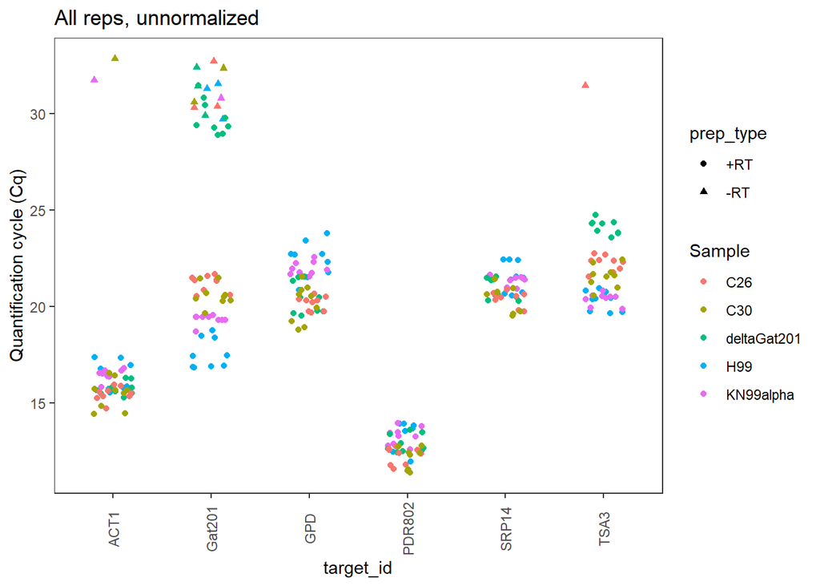

```r
ggplot(data = plate1_sep) +
  geom_point(aes(x = target_id, y = cq, shape = prep_type, colour = Sample),
    position = position_jitter(width = 0.2, height = 0)
  ) +
  labs(
    y = "Quantification cycle (Cq)",
    title = "All reps, unnormalized"
  ) +
    theme(axis.text.x = element_text(angle = 90, vjust = 0.5))
```

## Check reference genes plate 1

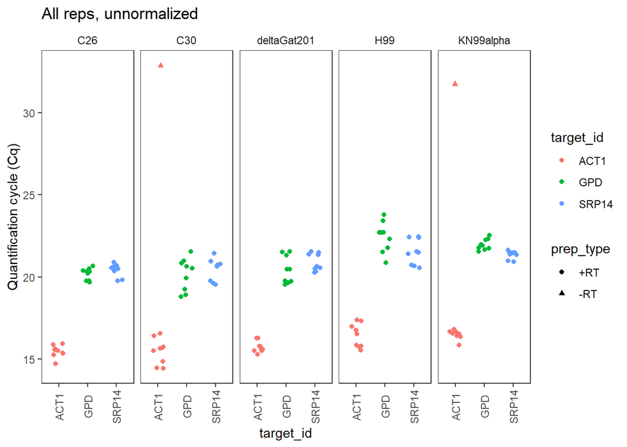

```r
  ggplot(data = filter(plate1_sep, target_id == c("SRP14", "ACT1", "GPD") )) +
  geom_point(aes(x = target_id, y = cq, shape = prep_type, colour = target_id),
    position = position_jitter(width = 0.2, height = 0)
  ) +
  labs(
    y = "Quantification cycle (Cq)",
    title = "All reps, unnormalized"
  ) +
  facet_grid(~Sample) +
  theme(axis.text.x = element_text(angle = 90, vjust = 0.5))
```

ACT1 has a lower Ct value then SRP14 and GPD, indicating higher mRNA expression in these conditions.

## Normalize data with 3 reference genes plate 1

### Within sample normalizing

```r
plate1_norm <- plate1_sep %>%
  group_by(sample_id)%>%
  filter(prep_type == "+RT" )%>%
  calculate_deltacq_bysampleid(ref_target_ids = c("SRP14", "ACT1", "GPD"))

plate1_norm
```

```
## # A tibble: 270 × 21
##    Include Color Pos   Name        Cp Conce…¹ Stand…² Status well     cq well_…³
##    <lgl>   <dbl> <chr> <chr>    <dbl> <lgl>     <dbl> <lgl>  <chr> <dbl> <fct>
##  1 TRUE      255 J1    Sample …  21.7 NA            0 NA     J1     21.7 J
##  2 TRUE      255 J2    Sample …  22.7 NA            0 NA     J2     22.7 J
##  3 TRUE      255 J3    Sample …  12.6 NA            0 NA     J3     12.6 J
##  4 TRUE      255 J4    Sample …  20.5 NA            0 NA     J4     20.5 J
##  5 TRUE      255 J5    Sample …  15.9 NA            0 NA     J5     15.9 J
##  6 TRUE      255 J6    Sample …  20.4 NA            0 NA     J6     20.4 J
##  7 TRUE      255 J7    Sample …  21.4 NA            0 NA     J7     21.4 J
##  8 TRUE      255 J8    Sample …  22.4 NA            0 NA     J8     22.4 J
##  9 TRUE      255 J9    Sample …  12.6 NA            0 NA     J9     12.6 J
## 10 TRUE      255 J10   Sample …  20.9 NA            0 NA     J10    20.9 J
## # … with 260 more rows, 10 more variables: well_col <fct>, prep_type <fct>,
## #   tech_rep <fct>, target_id <chr>, sample_id <chr>, Sample <chr>,
## #   BioRep <chr>, ref_cq <dbl>, delta_cq <dbl>, rel_abund <dbl>, and
## #   abbreviated variable names ¹Concentration, ²Standard, ³well_row
```

## Normalise data with ACT1 reference gene only plate 1

Test normalization with single reference gene since expression of AC T1 is greater than the other 2 reference genes.

```r
plate1_norm_ACT1 <- plate1_sep %>%
  group_by(sample_id)%>%
  filter(prep_type == "+RT" )%>%
  calculate_deltacq_bysampleid(ref_target_ids = c( "ACT1"))

plate1_norm_ACT1
```

```
## # A tibble: 270 × 21
##    Include Color Pos   Name        Cp Conce…¹ Stand…² Status well     cq well_…³
##    <lgl>   <dbl> <chr> <chr>    <dbl> <lgl>     <dbl> <lgl>  <chr> <dbl> <fct>
##  1 TRUE      255 J1    Sample …  21.7 NA            0 NA     J1     21.7 J
##  2 TRUE      255 J2    Sample …  22.7 NA            0 NA     J2     22.7 J
##  3 TRUE      255 J3    Sample …  12.6 NA            0 NA     J3     12.6 J
##  4 TRUE      255 J4    Sample …  20.5 NA            0 NA     J4     20.5 J
##  5 TRUE      255 J5    Sample …  15.9 NA            0 NA     J5     15.9 J
##  6 TRUE      255 J6    Sample …  20.4 NA            0 NA     J6     20.4 J
##  7 TRUE      255 J7    Sample …  21.4 NA            0 NA     J7     21.4 J
##  8 TRUE      255 J8    Sample …  22.4 NA            0 NA     J8     22.4 J
##  9 TRUE      255 J9    Sample …  12.6 NA            0 NA     J9     12.6 J
## 10 TRUE      255 J10   Sample …  20.9 NA            0 NA     J10    20.9 J
## # … with 260 more rows, 10 more variables: well_col <fct>, prep_type <fct>,
## #   tech_rep <fct>, target_id <chr>, sample_id <chr>, Sample <chr>,
## #   BioRep <chr>, ref_cq <dbl>, delta_cq <dbl>, rel_abund <dbl>, and
## #   abbreviated variable names ¹Concentration, ²Standard, ³well_row
```

## Plot delta Cq for normalized data plate1 ref genes

Use these data frames to plot with and without reference genes: “plate1_norm” for all genes and strains “plot1” for non-ref genes only without H99 “plotr” for ref genes only

```r
plot1 <- (data = filter(plate1_norm, target_id != c("SRP14", "ACT1", "GPD"), Sample != c("H99" )))
```

```r
plot1r <- (data = filter(plate1_norm, target_id == c("SRP14", "ACT1", "GPD"), Sample != c("H99" )))
```

## Plot delta Cq for normalized data

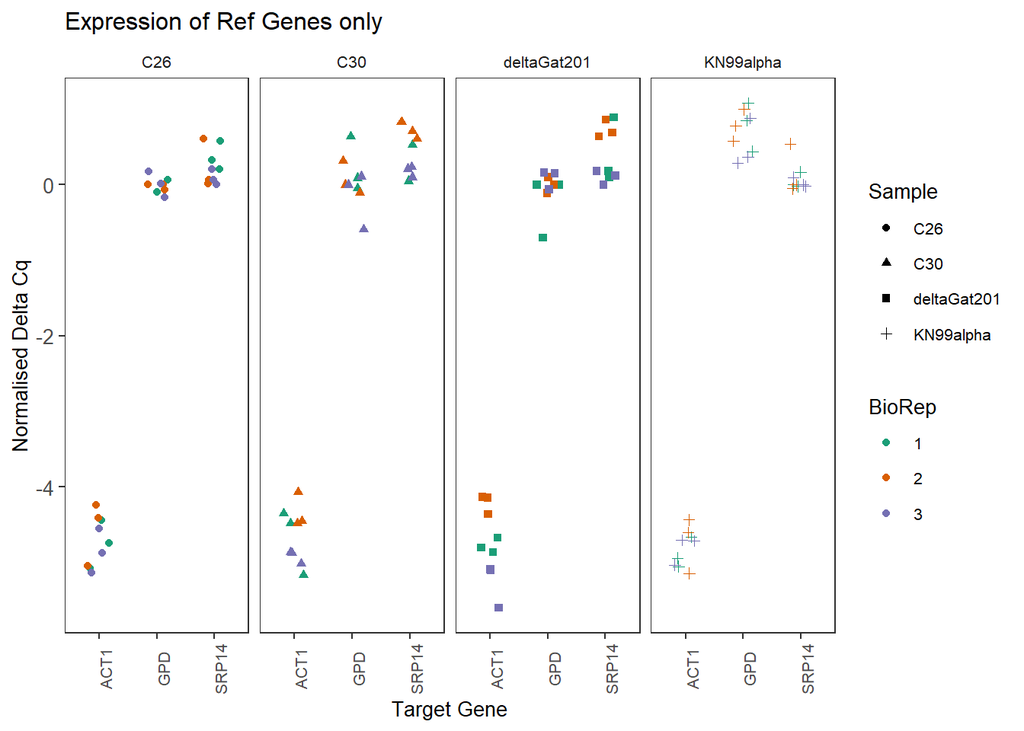

```r
ggplot(data = plot1r ) +
  geom_point(aes(x = target_id, y = delta_cq, shape = Sample, colour = BioRep ),
    position = position_jitter(width = 0.2, height = 0)
  ) +

  labs(x = "Target Gene",
       y = "Normalised Delta Cq",
       title = "Expression of Ref Genes only") +
  facet_wrap(~Sample, ncol = 5)+
    theme(text = element_text(size = 10)) +
    theme(axis.text.x = element_text(size = 8, angle = 90))+
    theme(axis.text.y = element_text(size= 10))+
    scale_color_brewer(palette="Dark2")
```

“plate1_norm”: GPD and SRP14 have a Cq=0 in all samples. ACT1 has a Cq = -5 in all samples.

“plot1r”: Looking at the refernce genes alone you can see that ACT1 is expressed much higher that SRP14 and GPD.

Maybe should try normalising with SRP14 and GPD only?

## Save plots with all genes, only target genes and only reference genes plate 1

Change “ggplot(data = plot1)” to make each plot and change in plot name below before saving. “plate1_norm” for all genes and strains “plot1” for non-ref genes only without H99 “plot1r” for ref genes only

```r
ggsave("../Results/plot1r.png",
 ,width = 10,height=7)
```

```r
plate1_med <- plate1_norm %>%
  group_by(sample_id, Sample, target_id) %>%
  summarize(
    delta_cq  = median(delta_cq, na.rm = TRUE),
    rel_abund = median(rel_abund, na.rm = TRUE)
  )

plate1_med
```

```
## # A tibble: 90 × 5
## # Groups:   sample_id, Sample [15]
##    sample_id Sample target_id delta_cq rel_abund
##    <chr>     <chr>  <chr>        <dbl>     <dbl>
##  1 C26-1     C26    ACT1        -4.74     26.7
##  2 C26-1     C26    Gat201       1.07      0.476
##  3 C26-1     C26    GPD          0         1
##  4 C26-1     C26    PDR802      -7.74    214.
##  5 C26-1     C26    SRP14        0.330     0.796
##  6 C26-1     C26    TSA3         2.07      0.238
##  7 C26-2     C26    ACT1        -4.41     21.3
##  8 C26-2     C26    Gat201       0.84      0.559
##  9 C26-2     C26    GPD          0         1
## 10 C26-2     C26    PDR802      -7.97    251.
## # … with 80 more rows
```

### Filter plate1_med for individual genes Gat201, PDR802 and TSA3

Filtering by gene makes it easier to digest the data.

```r
filter(plate1_med, target_id == "Gat201")
```

```
## # A tibble: 15 × 5
## # Groups:   sample_id, Sample [15]
##    sample_id     Sample      target_id delta_cq rel_abund
##    <chr>         <chr>       <chr>        <dbl>     <dbl>
##  1 C26-1         C26         Gat201      1.07     0.476
##  2 C26-2         C26         Gat201      0.84     0.559
##  3 C26-3         C26         Gat201      0.990    0.503
##  4 C30-1         C30         Gat201      0.550    0.683
##  5 C30-2         C30         Gat201      1.36     0.390
##  6 C30-3         C30         Gat201     -0.0100   1.01
##  7 deltaGat201-1 deltaGat201 Gat201      9.3      0.00159
##  8 deltaGat201-2 deltaGat201 Gat201      9.62     0.00127
##  9 deltaGat201-3 deltaGat201 Gat201      8.03     0.00383
## 10 H99-1         H99         Gat201     -3.94    15.3
## 11 H99-2         H99         Gat201     -4.61    24.4
## 12 H99-3         H99         Gat201     -3.22     9.32
## 13 KN99alpha-1   KN99alpha   Gat201     -2.16     4.47
## 14 KN99alpha-2   KN99alpha   Gat201     -1.51     2.85
## 15 KN99alpha-3   KN99alpha   Gat201     -1.91     3.76
```

```r
filter(plate1_med, target_id == "PDR802")
```

```
## # A tibble: 15 × 5
## # Groups:   sample_id, Sample [15]
##    sample_id     Sample      target_id delta_cq rel_abund
##    <chr>         <chr>       <chr>        <dbl>     <dbl>
##  1 C26-1         C26         PDR802       -7.74      214.
##  2 C26-2         C26         PDR802       -7.97      251.
##  3 C26-3         C26         PDR802       -8.08      271.
##  4 C30-1         C30         PDR802       -8.13      280.
##  5 C30-2         C30         PDR802       -7.42      171.
##  6 C30-3         C30         PDR802       -8.13      280.
##  7 deltaGat201-1 deltaGat201 PDR802       -7.85      231.
##  8 deltaGat201-2 deltaGat201 PDR802       -7.11      138.
##  9 deltaGat201-3 deltaGat201 PDR802       -7.9       239.
## 10 H99-1         H99         PDR802       -8.49      360.
## 11 H99-2         H99         PDR802       -7.84      229.
## 12 H99-3         H99         PDR802       -8.21      296.
## 13 KN99alpha-1   KN99alpha   PDR802       -7.67      204.
## 14 KN99alpha-2   KN99alpha   PDR802       -8.11      276.
## 15 KN99alpha-3   KN99alpha   PDR802       -8.11      276.
```

```r
filter(plate1_med, target_id == "TSA3")
```

```
## # A tibble: 15 × 5
## # Groups:   sample_id, Sample [15]
##    sample_id     Sample      target_id delta_cq rel_abund
##    <chr>         <chr>       <chr>        <dbl>     <dbl>
##  1 C26-1         C26         TSA3         2.07     0.238
##  2 C26-2         C26         TSA3         2.04     0.243
##  3 C26-3         C26         TSA3         1.93     0.262
##  4 C30-1         C30         TSA3         1.39     0.382
##  5 C30-2         C30         TSA3         2.06     0.240
##  6 C30-3         C30         TSA3         1.09     0.470
##  7 deltaGat201-1 deltaGat201 TSA3         3.82     0.0708
##  8 deltaGat201-2 deltaGat201 TSA3         4.17     0.0556
##  9 deltaGat201-3 deltaGat201 TSA3         2.99     0.126
## 10 H99-1         H99         TSA3        -1.62     3.07
## 11 H99-2         H99         TSA3        -1.10     2.14
## 12 H99-3         H99         TSA3        -0.900    1.87
## 13 KN99alpha-1   KN99alpha   TSA3        -0.890    1.85
## 14 KN99alpha-2   KN99alpha   TSA3        -0.540    1.45
## 15 KN99alpha-3   KN99alpha   TSA3        -1        2
```

## Plot relative abundance for normalized data plate 1

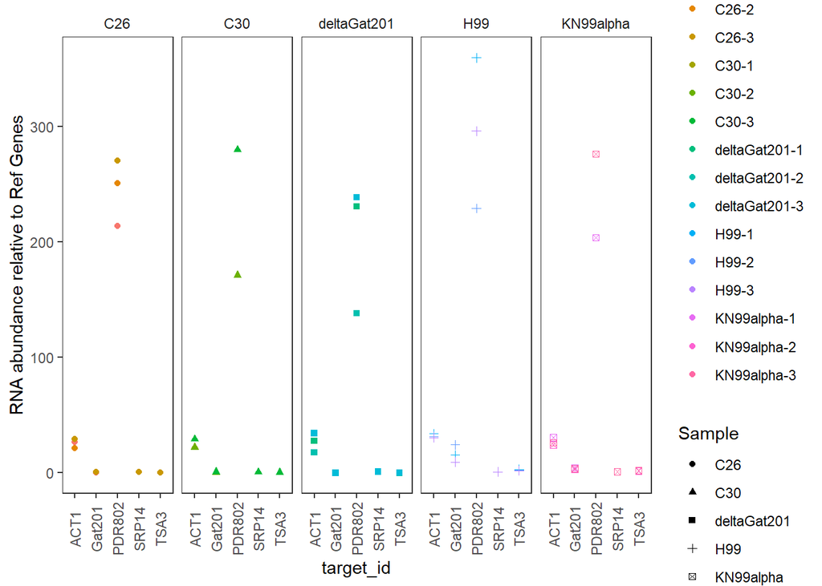

```r
ggplot(data = filter(plate1_med, target_id != c("SRP14", "ACT1", "GPD"))) +
  geom_point(aes(x = target_id, y = rel_abund, shape = Sample, colour = sample_id)) +
  labs(   y = "RNA abundance relative to Ref Genes" ) +
  facet_wrap(~Sample, ncol=5) +
  theme(axis.text.x = element_text(angle = 90, vjust = 0.5))
```

## Plot delta Cq for normalized data with ACT1 only plate 1

```r
plot1_ACT1 <- (data = filter(plate1_norm_ACT1, target_id != c("SRP14", "ACT1", "GPD"), Sample != c("H99" )))
```

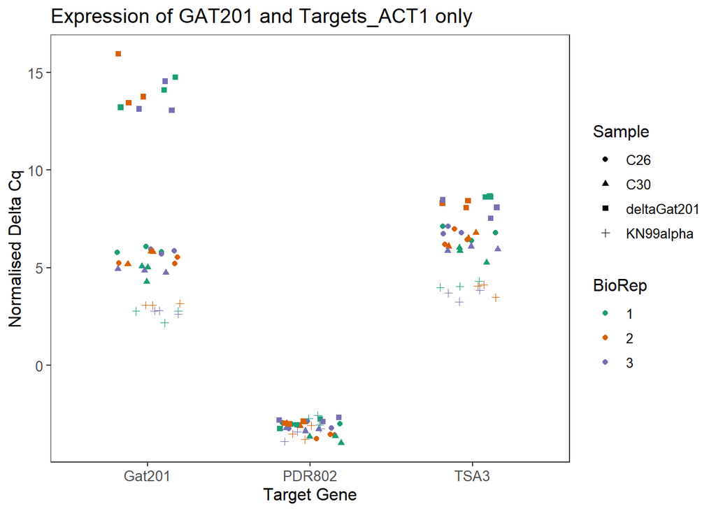

```r
ggplot(data = plot1_ACT1) +
  geom_point(aes(x = target_id, y = delta_cq, shape = Sample, colour = BioRep ),
    position = position_jitter(width = 0.2, height = 0)
  ) +

  labs(x = "Target Gene",
       y = "Normalised Delta Cq",
       title = "Expression of GAT201 and Targets_ACT1 only") +
    theme(text = element_text(size = 12)) +
    theme(axis.text.x = element_text(size = 10))+
    theme(axis.text.y = element_text(size= 10))+
    scale_color_brewer(palette="Dark2")
```

## Save plot with only target genes normalised by ACT1 only

```r
ggsave("../Results/Plate1_norm_ACT1.png",
 ,width = 10,height=7)
```

## Doubly normalized data: delta delta Cq plate 1

### Calculate delta delta cq against a chosen reference sample KN99-alpha (WT)

This is an estimate of log2 fold change. Compare WT to other strains in the same growth conditions

```r
plate1_deltanorm <- plate1_med %>%
  calculate_deltadeltacq_bytargetid(ref_sample_ids = "KN99alpha-1")

plate1_deltanorm_med <- plate1_deltanorm %>%
    group_by(sample_id, Sample, target_id) %>%
  summarize(
    deltadelta_cq  = median(deltadelta_cq, na.rm = TRUE),
    fold_change    = median(fold_change,   na.rm = TRUE)
  )

plate1_deltanorm
```

```
## # A tibble: 90 × 8
##    sample_id     Sample      target_id delta_cq rel_ab…¹ ref_d…² delta…³ fold_…⁴
##    <chr>         <chr>       <chr>        <dbl>    <dbl>   <dbl>   <dbl>   <dbl>
##  1 C26-1         C26         ACT1         -4.74     26.7   -4.94 -0.200    0.871
##  2 C26-2         C26         ACT1         -4.41     21.3   -4.94 -0.530    0.693
##  3 C26-3         C26         ACT1         -4.87     29.2   -4.94 -0.0700   0.953
##  4 C30-1         C30         ACT1         -4.48     22.3   -4.94 -0.460    0.727
##  5 C30-2         C30         ACT1         -4.45     21.9   -4.94 -0.490    0.712
##  6 C30-3         C30         ACT1         -4.87     29.2   -4.94 -0.0700   0.953
##  7 deltaGat201-1 deltaGat201 ACT1         -4.8      27.9   -4.94 -0.140    0.908
##  8 deltaGat201-2 deltaGat201 ACT1         -4.14     17.6   -4.94 -0.800    0.574
##  9 deltaGat201-3 deltaGat201 ACT1         -5.1      34.3   -4.94  0.160    1.12
## 10 H99-1         H99         ACT1         -5.09     34.1   -4.94  0.150    1.11
## # … with 80 more rows, and abbreviated variable names ¹rel_abund,
## #   ²ref_delta_cq, ³deltadelta_cq, ⁴fold_change
```

```r
plate1_deltanorm_med
```

```
## # A tibble: 90 × 5
## # Groups:   sample_id, Sample [15]
##    sample_id Sample target_id deltadelta_cq fold_change
##    <chr>     <chr>  <chr>             <dbl>       <dbl>
##  1 C26-1     C26    ACT1            -0.200        0.871
##  2 C26-1     C26    Gat201          -3.23         0.107
##  3 C26-1     C26    GPD              0.850        1.80
##  4 C26-1     C26    PDR802           0.0700       1.05
##  5 C26-1     C26    SRP14           -0.330        0.796
##  6 C26-1     C26    TSA3            -2.96         0.129
##  7 C26-2     C26    ACT1            -0.530        0.693
##  8 C26-2     C26    Gat201          -3            0.125
##  9 C26-2     C26    GPD              0.850        1.80
## 10 C26-2     C26    PDR802           0.300        1.23
## # … with 80 more rows
```

## Plot delta delta Cq (log2-fold change) for each target gene plate 1

Here, delta delta Cq is positive when a target is more highly detected in the relevant sample, compared to reference samples.

[figure not shown]

```r
ggplot(data = filter(plate1_deltanorm_med, target_id != "SRP14") ) +
  geom_line(aes(x = target_id, y = deltadelta_cq, colour = sample_id, group = sample_id)) +
  geom_point(aes(x = target_id, y = deltadelta_cq,  colour = sample_id)) +
  labs(
    y = "delta delta Cq (log2 fold change)\n relative to H99"
  ) +
    facet_wrap(~Sample, ncol=5) +
    theme(axis.text.x = element_text(angle = 90, vjust = 0.5, size = 8))+
    theme(text = element_text(size = 9)) +
    theme(axis.text.x = element_text(size = 10))+
    theme(axis.text.y = element_text(size= 10))
```

```r
ggsave("../Results/ddcq_plate1.png",
 width = 10,height=7)
```

## Plot fold change for each target gene plate 1

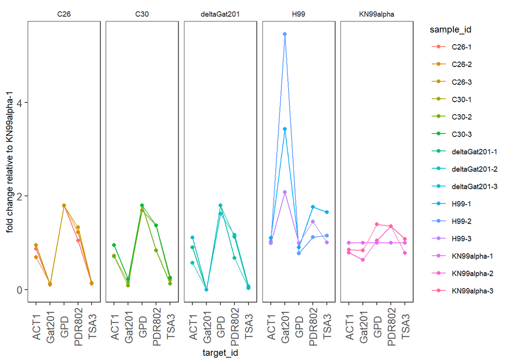

```r
ggplot(data = filter(plate1_deltanorm_med, target_id != "SRP14") ) +
  geom_line(aes(x = target_id, y = fold_change, colour = sample_id, group = sample_id)) +
  geom_point(aes(x = target_id, y = fold_change, colour = sample_id)) +
  labs(
    y = "fold change relative to KN99alpha-1"
  ) +
  facet_wrap(~Sample,ncol=5) +
  theme(axis.text.x = element_text(angle = 90, vjust = 0.5, size = 8))+
    theme(text = element_text(size = 9)) +
    theme(axis.text.x = element_text(size = 10))+
    theme(axis.text.y = element_text(size= 10))
```

## Save fold change relative to KN99alpha-1 plot1

```r
ggsave("../Results/fc_plate1.png",
 width = 10,height=7)
```

# Plate 2

## Create Plateplan 2

### list target_ids of primer sets

```r
colkey <- create_colkey_6_in_24(target_id = c("BLP1", "MEU1", "MEP1", "SRP14", "ACT1", "GPD"))

print(colkey)
```

```
## # A tibble: 24 × 4
##    well_col prep_type tech_rep target_id
##    <fct>    <fct>     <fct>    <chr>
##  1 1        +RT       1        BLP1
##  2 2        +RT       1        MEU1
##  3 3        +RT       1        MEP1
##  4 4        +RT       1        SRP14
##  5 5        +RT       1        ACT1
##  6 6        +RT       1        GPD
##  7 7        +RT       2        BLP1
##  8 8        +RT       2        MEU1
##  9 9        +RT       2        MEP1
## 10 10       +RT       2        SRP14
## # … with 14 more rows
```

## Set up experimental samples plate 2

### List sample name, BioRep (3) and TechRep (3)

```r
Samples <- c("H99-1", "H99-2", "H99-3", "KN99alpha-1", "KN99alpha-2", "KN99alpha-3", "deltaGat201-1", "deltaGat201-2", "deltaGat201-3", "C26-1", "C26-2", "C26-3", "C30-1", "C30-2", "C30-3")

TechReps <- c("1", "2", "3")

rowkey <- tibble(well_row=LETTERS[1:15],
                 sample_id= Samples)

print(rowkey)
```

```
## # A tibble: 15 × 2
##    well_row sample_id
##    <chr>    <chr>
##  1 A        H99-1
##  2 B        H99-2
##  3 C        H99-3
##  4 D        KN99alpha-1
##  5 E        KN99alpha-2
##  6 F        KN99alpha-3
##  7 G        deltaGat201-1
##  8 H        deltaGat201-2
##  9 I        deltaGat201-3
## 10 J        C26-1
## 11 K        C26-2
## 12 L        C26-3
## 13 M        C30-1
## 14 N        C30-2
## 15 O        C30-3
```

## Plateplan2

```r
plate2 <- label_plate_rowcol(
  plate = create_blank_plate(well_row = LETTERS[1:15], well_col = 1:24),
  rowkey = rowkey,
  colkey = colkey
)

print(plate2)
```

```
## # A tibble: 360 × 7
##    well  well_row well_col prep_type tech_rep target_id sample_id
##    <chr> <fct>    <fct>    <fct>     <fct>    <chr>     <chr>
##  1 A1    A        1        +RT       1        BLP1      H99-1
##  2 A2    A        2        +RT       1        MEU1      H99-1
##  3 A3    A        3        +RT       1        MEP1      H99-1
##  4 A4    A        4        +RT       1        SRP14     H99-1
##  5 A5    A        5        +RT       1        ACT1      H99-1
##  6 A6    A        6        +RT       1        GPD       H99-1
##  7 A7    A        7        +RT       2        BLP1      H99-1
##  8 A8    A        8        +RT       2        MEU1      H99-1
##  9 A9    A        9        +RT       2        MEP1      H99-1
## 10 A10   A        10       +RT       2        SRP14     H99-1
## # … with 350 more rows
```

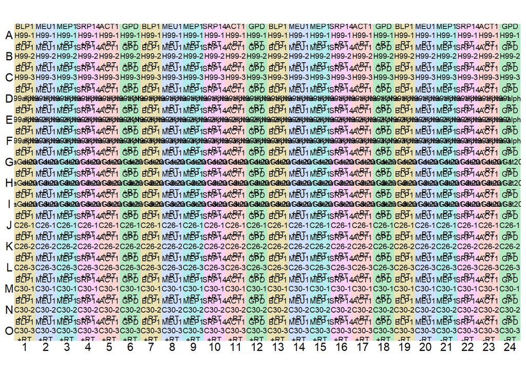

```r
display_plate_qpcr(plate2)
```

## Load data for plate 2

```r
plate2 <- read_tsv( "../data/EH_20230112_CryptoMob_plate2_Ct.txt",
                    skip=1) %>%
    mutate(well=Pos,cq=Cp) %>%
    right_join(plate2)
```

```r
plate2_sep <- separate(plate2,
         sample_id,
         into = c("Sample" , "BioRep"),
         sep = "-",
         remove = FALSE)
```

## Plot all reps, unnormalized plate 2

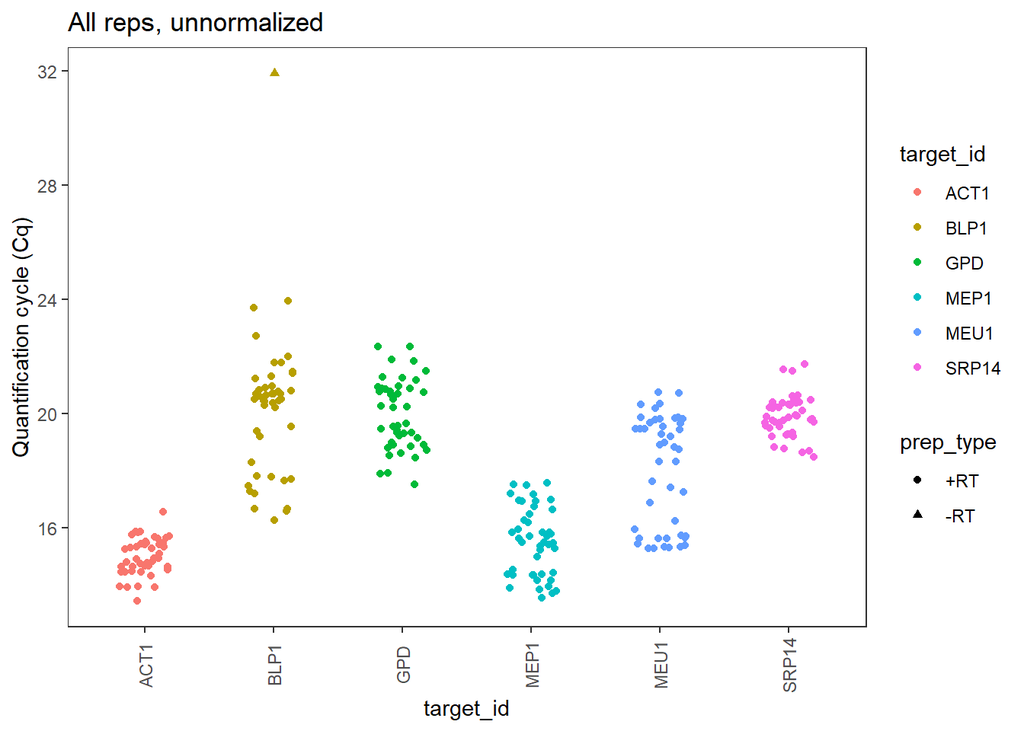

```r
ggplot(data = plate2_sep) +
  geom_point(aes(x = target_id, y = cq, shape = prep_type, colour = target_id),
    position = position_jitter(width = 0.2, height = 0)
  ) +
  labs(
    y = "Quantification cycle (Cq)",
    title = "All reps, unnormalized"
  ) +
    theme(axis.text.x = element_text(angle = 90, vjust = 0.5))
```

## Check reference genes plate 2

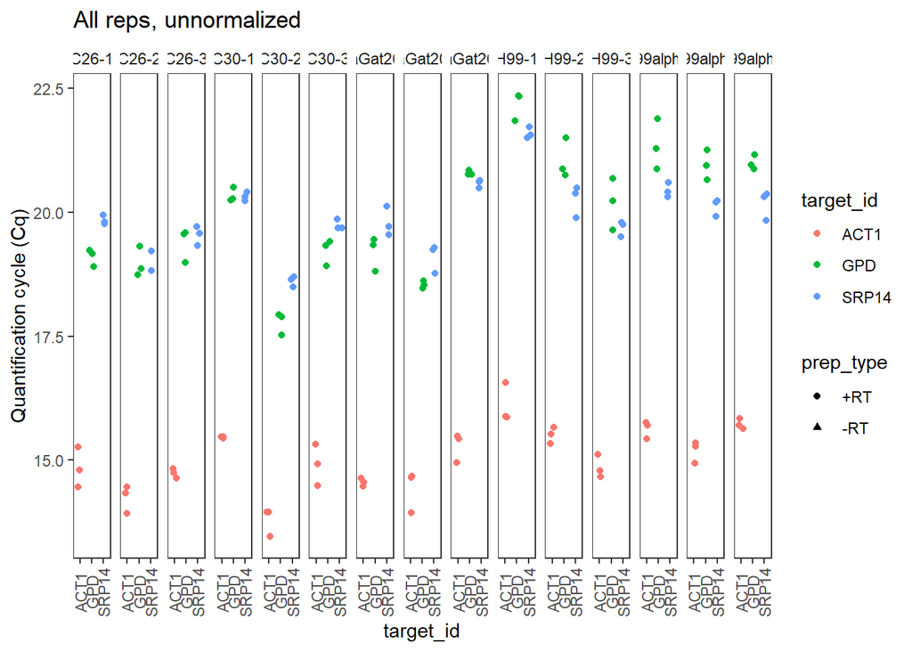

```r
  ggplot(data = filter(plate2_sep, target_id == c("SRP14", "ACT1", "GPD") )) +
  geom_point(aes(x = target_id, y = cq, shape = prep_type, colour = target_id),
    position = position_jitter(width = 0.2, height = 0)
  ) +
  labs(
    y = "Quantification cycle (Cq)",
    title = "All reps, unnormalized"
  ) +
  facet_grid(~sample_id) +
  theme(axis.text.x = element_text(angle = 90, vjust = 0.5))
```

## Normalize data with 3 reference genes plate 2

### Within sample normalizing

```r
plate2_norm <- plate2_sep %>%
  group_by(sample_id)%>%
  filter(prep_type == "+RT" )%>%
  calculate_deltacq_bysampleid(ref_target_ids = c("SRP14", "ACT1", "GPD"))
```

## Normalise data with ACT1 reference gene only plate 2

```r
plate2_norm_ACT1 <- plate2_sep %>%
  group_by(sample_id)%>%
  filter(prep_type == "+RT" )%>%
  calculate_deltacq_bysampleid(ref_target_ids = c( "ACT1"))
```

## Plot delta Cq for normalized data plate2 ref genes

### plate2_norm for all genes and strains

### plot2 for non-ref genes only without H99

### plot2r for ref genes only

```r
plot2 <- (data = filter(plate2_norm, target_id != c("SRP14", "ACT1", "GPD"), Sample != c("H99" )))
```

```r
plot2r <- (data = filter(plate2_norm, target_id == c("SRP14", "ACT1", "GPD"), Sample != c("H99" )))
```

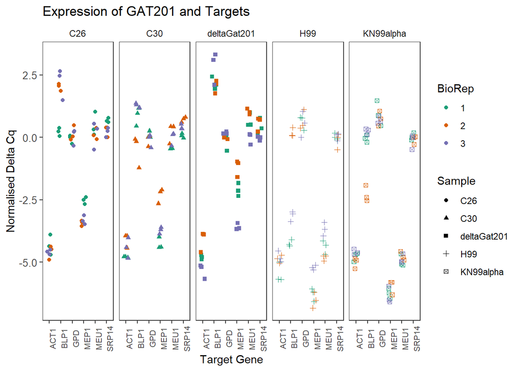

```r
ggplot(data = plate2_norm ) +
  geom_point(aes(x = target_id, y = delta_cq, shape = Sample, colour = BioRep ),
    position = position_jitter(width = 0.2, height = 0)
  ) +

  labs(x = "Target Gene",
       y = "Normalised Delta Cq",
       title = "Expression of GAT201 and Targets") +
  facet_wrap(~Sample, ncol = 5)+
    theme(text = element_text(size = 11)) +
    theme(axis.text.x = element_text(size = 8, angle = 90))+
    theme(axis.text.y = element_text(size= 10))+
    scale_color_brewer(palette="Dark2")
```

The reference genes show the same expression as plate 1 with ACT1 being expressed higher than SRP14 and GPD.

The target gene BLP1 is expressed similarly in deltaGat201 and the complemented strains. It is expressed More in KN99alpha. This is the same for MEP1 and MEU1. This suggests the complementation is not acting on GAT201 target genes in the same way as wild type. This could be because expression of GAT201 is less in the complemented strains compared to WT.

## Save plots with all genes, only target genes and only reference genes plate 2

```r
ggsave("../Results/plate2_norm.png",
 ,width = 10,height=7)
```

```r
plate2_med <- plate2_norm %>%
  group_by(sample_id, Sample, target_id) %>%
  summarize(
    delta_cq  = median(delta_cq, na.rm = TRUE),
    rel_abund = median(rel_abund, na.rm = TRUE)
  )
```

### Filter plate2_med for individual genes

```r
filter(plate2_med, target_id == "BLP1")
```

```
## # A tibble: 15 × 5
## # Groups:   sample_id, Sample [15]
##    sample_id     Sample      target_id delta_cq rel_abund
##    <chr>         <chr>       <chr>        <dbl>     <dbl>
##  1 C26-1         C26         BLP1        0.240      0.847
##  2 C26-2         C26         BLP1        2.07       0.238
##  3 C26-3         C26         BLP1        2.46       0.182
##  4 C30-1         C30         BLP1        0.970      0.511
##  5 C30-2         C30         BLP1       -0.170      1.13
##  6 C30-3         C30         BLP1        1.3        0.406
##  7 deltaGat201-1 deltaGat201 BLP1        2.12       0.230
##  8 deltaGat201-2 deltaGat201 BLP1        2.15       0.225
##  9 deltaGat201-3 deltaGat201 BLP1        3.10       0.117
## 10 H99-1         H99         BLP1       -4.28      19.4
## 11 H99-2         H99         BLP1        0.0900     0.940
## 12 H99-3         H99         BLP1       -3.06       8.34
## 13 KN99alpha-1   KN99alpha   BLP1       -0.0300     1.02
## 14 KN99alpha-2   KN99alpha   BLP1       -2.4        5.28
## 15 KN99alpha-3   KN99alpha   BLP1        0.300      0.812
```

```r
filter(plate2_med, target_id == "MEU1")
```

```
## # A tibble: 15 × 5
## # Groups:   sample_id, Sample [15]
##    sample_id     Sample      target_id delta_cq rel_abund
##    <chr>         <chr>       <chr>        <dbl>     <dbl>
##  1 C26-1         C26         MEU1        0.310      0.807
##  2 C26-2         C26         MEU1        0.0900     0.940
##  3 C26-3         C26         MEU1        0.340      0.790
##  4 C30-1         C30         MEU1       -0.440      1.36
##  5 C30-2         C30         MEU1        0.430      0.742
##  6 C30-3         C30         MEU1        0.110      0.927
##  7 deltaGat201-1 deltaGat201 MEU1        0.510      0.702
##  8 deltaGat201-2 deltaGat201 MEU1        1.01       0.497
##  9 deltaGat201-3 deltaGat201 MEU1        0.100      0.933
## 10 H99-1         H99         MEU1       -4.31      19.8
## 11 H99-2         H99         MEU1       -4.75      26.9
## 12 H99-3         H99         MEU1       -3.68      12.8
## 13 KN99alpha-1   KN99alpha   MEU1       -5.07      33.6
## 14 KN99alpha-2   KN99alpha   MEU1       -4.79      27.7
## 15 KN99alpha-3   KN99alpha   MEU1       -4.96      31.1
```

```r
filter(plate2_med, target_id == "MEP1")
```

```
## # A tibble: 15 × 5
## # Groups:   sample_id, Sample [15]
##    sample_id     Sample      target_id delta_cq rel_abund
##    <chr>         <chr>       <chr>        <dbl>     <dbl>
##  1 C26-1         C26         MEP1         -2.5       5.66
##  2 C26-2         C26         MEP1         -3.4      10.6
##  3 C26-3         C26         MEP1         -3.36     10.3
##  4 C30-1         C30         MEP1         -4.39     21.0
##  5 C30-2         C30         MEP1         -2.18      4.53
##  6 C30-3         C30         MEP1         -3.69     12.9
##  7 deltaGat201-1 deltaGat201 MEP1         -2.14      4.41
##  8 deltaGat201-2 deltaGat201 MEP1         -1.03      2.04
##  9 deltaGat201-3 deltaGat201 MEP1         -3.64     12.5
## 10 H99-1         H99         MEP1         -6.19     73.0
## 11 H99-2         H99         MEP1         -6.52     91.8
## 12 H99-3         H99         MEP1         -5.21     37.0
## 13 KN99alpha-1   KN99alpha   MEP1         -6.23     75.1
## 14 KN99alpha-2   KN99alpha   MEP1         -5.8      55.7
## 15 KN99alpha-3   KN99alpha   MEP1         -6.51     91.1
```

## Plot relative abundance for normalized data plate 2 ref genes

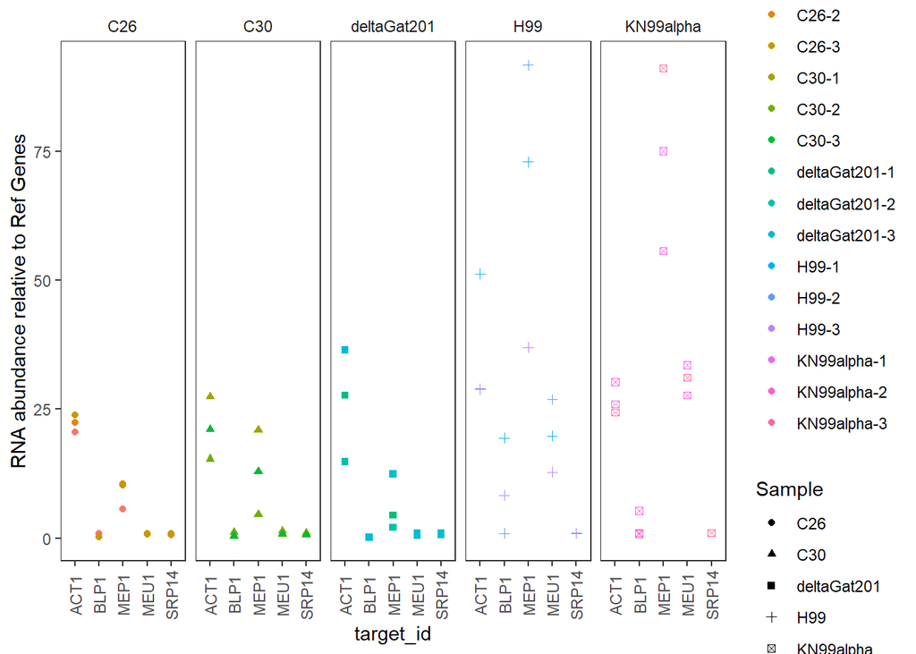

```r
ggplot(data = filter(plate2_med, target_id != c("SRP14", "ACT1", "GPD"))) +
  geom_point(aes(x = target_id, y = rel_abund, shape = Sample, colour = sample_id)) +
  labs(   y = "RNA abundance relative to Ref Genes" ) +
  facet_wrap(~Sample, ncol=5) +
  theme(axis.text.x = element_text(angle = 90, vjust = 0.5))
```

## Plot delta Cq for normalized data with ACT1 only plate 2

```r
plot2_ACT1 <- (data = filter(plate2_norm_ACT1, target_id != c("SRP14", "ACT1", "GPD"), Sample != c("H99" )))
```

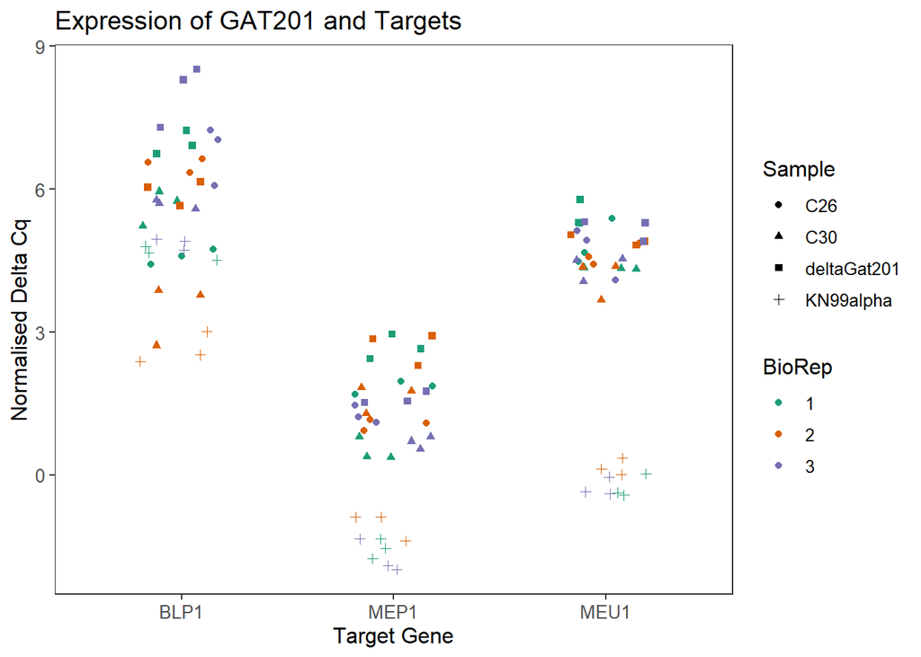

```r
ggplot(data = plot2_ACT1) +
  geom_point(aes(x = target_id, y = delta_cq, shape = Sample, colour = BioRep ),
    position = position_jitter(width = 0.2, height = 0)
  ) +

  labs(x = "Target Gene",
       y = "Normalised Delta Cq",
       title = "Expression of GAT201 and Targets") +
    theme(text = element_text(size = 12)) +
    theme(axis.text.x = element_text(size = 10))+
    theme(axis.text.y = element_text(size= 10))+
    scale_color_brewer(palette="Dark2")
```

## Save plot normalized data with ACT1 only plate 2

```r
ggsave("../Results/plate2_norm_ACT1.png",
 ,width = 10,height=7)
```

## Doubly normalized data: delta delta Cq plate 2

### Calculate delta delta cq against a chosen reference sample KN99-alpha (WT)

This is an estimate of log2 fold change. plate2 Compare WT to other strains in the same growth conditions

```r
plate2_deltanorm <- plate2_med %>%
  calculate_deltadeltacq_bytargetid(ref_sample_ids = "KN99alpha-1")

plate2_deltanorm_med <- plate2_deltanorm %>%
    group_by(sample_id, Sample, target_id) %>%
  summarize(
    deltadelta_cq  = median(deltadelta_cq, na.rm = TRUE),
    fold_change    = median(fold_change,   na.rm = TRUE)
  )

plate2_deltanorm
```

```
## # A tibble: 90 × 8
##    sample_id     Sample      target_id delta_cq rel_ab…¹ ref_d…² delta…³ fold_…⁴
##    <chr>         <chr>       <chr>        <dbl>    <dbl>   <dbl>   <dbl>   <dbl>
##  1 C26-1         C26         ACT1         -4.36     20.5    -4.7 -0.34     0.790
##  2 C26-2         C26         ACT1         -4.49     22.5    -4.7 -0.210    0.865
##  3 C26-3         C26         ACT1         -4.58     23.9    -4.7 -0.120    0.920
##  4 C30-1         C30         ACT1         -4.78     27.5    -4.7  0.0800   1.06
##  5 C30-2         C30         ACT1         -3.94     15.3    -4.7 -0.760    0.590
##  6 C30-3         C30         ACT1         -4.4      21.1    -4.7 -0.300    0.812
##  7 deltaGat201-1 deltaGat201 ACT1         -4.79     27.7    -4.7  0.0900   1.06
##  8 deltaGat201-2 deltaGat201 ACT1         -3.89     14.8    -4.7 -0.810    0.570
##  9 deltaGat201-3 deltaGat201 ACT1         -5.19     36.5    -4.7  0.490    1.40
## 10 H99-1         H99         ACT1         -5.68     51.3    -4.7  0.980    1.97
## # … with 80 more rows, and abbreviated variable names ¹rel_abund,
## #   ²ref_delta_cq, ³deltadelta_cq, ⁴fold_change
```

```r
plate2_deltanorm_med
```

```
## # A tibble: 90 × 5
## # Groups:   sample_id, Sample [15]
##    sample_id Sample target_id deltadelta_cq fold_change
##    <chr>     <chr>  <chr>             <dbl>       <dbl>
##  1 C26-1     C26    ACT1             -0.34       0.790
##  2 C26-1     C26    BLP1             -0.270      0.829
##  3 C26-1     C26    GPD               0.880      1.84
##  4 C26-1     C26    MEP1             -3.73       0.0754
##  5 C26-1     C26    MEU1             -5.38       0.0240
##  6 C26-1     C26    SRP14            -0.650      0.637
##  7 C26-2     C26    ACT1             -0.210      0.865
##  8 C26-2     C26    BLP1             -2.10       0.233
##  9 C26-2     C26    GPD               0.850      1.80
## 10 C26-2     C26    MEP1             -2.83       0.141
## # … with 80 more rows
```

## Plot delta delta Cq (log2-fold change) for each target gene in plate 2

Here, delta delta Cq is positive when a target is more highly detected in the relevant sample, compared to reference samples.

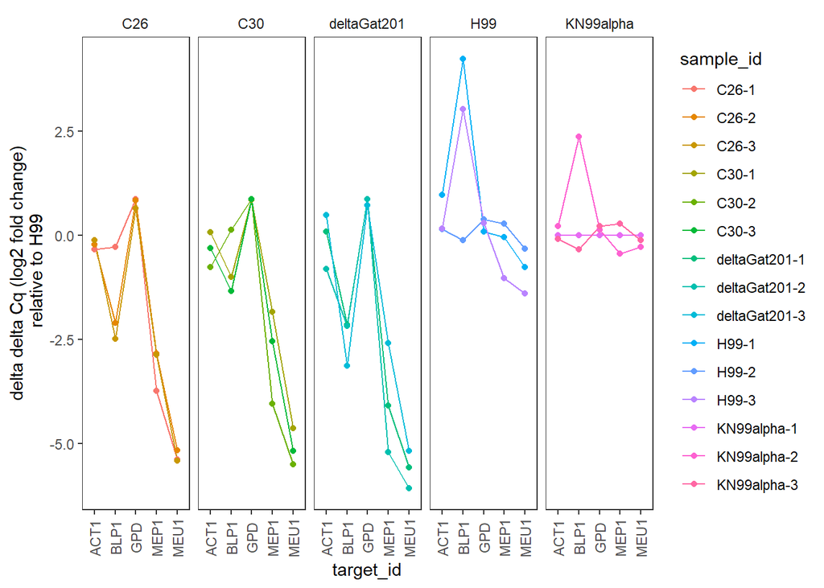

```r
ggplot(data = filter(plate2_deltanorm_med, target_id != "SRP14") ) +
  geom_line(aes(x = target_id, y = deltadelta_cq, colour = sample_id, group = sample_id)) +
  geom_point(aes(x = target_id, y = deltadelta_cq,  colour = sample_id)) +
  labs(
    y = "delta delta Cq (log2 fold change)\n relative to H99"
  ) +
  facet_wrap(~Sample, ncol=5) +
  theme(axis.text.x = element_text(angle = 90, vjust = 0.5))
```

```r
ggsave("../Results/ddcq_plate2.png",
 width = 10,height=7)
```

## Plot fold change for each target gene plate 2

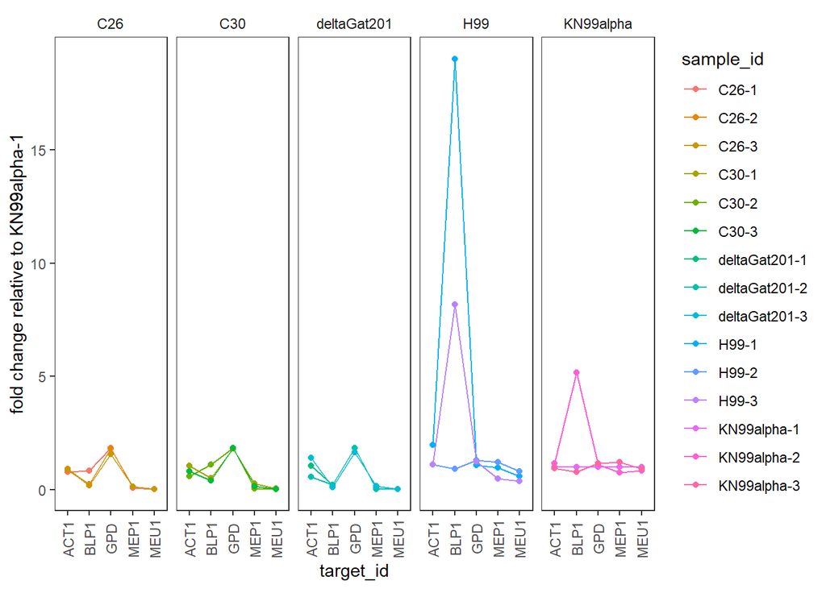

```r
ggplot(data = filter(plate2_deltanorm_med, target_id != "SRP14") ) +
  geom_line(aes(x = target_id, y = fold_change, colour = sample_id, group = sample_id)) +
  geom_point(aes(x = target_id, y = fold_change, colour = sample_id)) +
  labs(
    y = "fold change relative to KN99alpha-1"
  ) +
  facet_wrap(~Sample,ncol=5) +
  theme(axis.text.x = element_text(angle = 90, vjust = 0.5))
```

## Save fold change relative to KN99alpha-1 plot2

```r
ggsave("../Results/fc_plate2.png",
 width = 10,height=7)
```

# Combine plates together

```r
plates <- bind_rows(plate1_norm, plate2_norm)
```

## Plot delta Cq for normalized data combined plates

### plates for all genes and strains (normalised)

### plot_comb for non-ref genes only without H99

### plot_combr for ref genes only

```r
plot_comb <- (data = filter(plates, target_id != c("SRP14", "ACT1", "GPD"), Sample != c("H99" )))
```

```r
plot_combr <- (data = filter(plates, target_id == c("SRP14", "ACT1", "GPD"), Sample != c("H99" )))
```

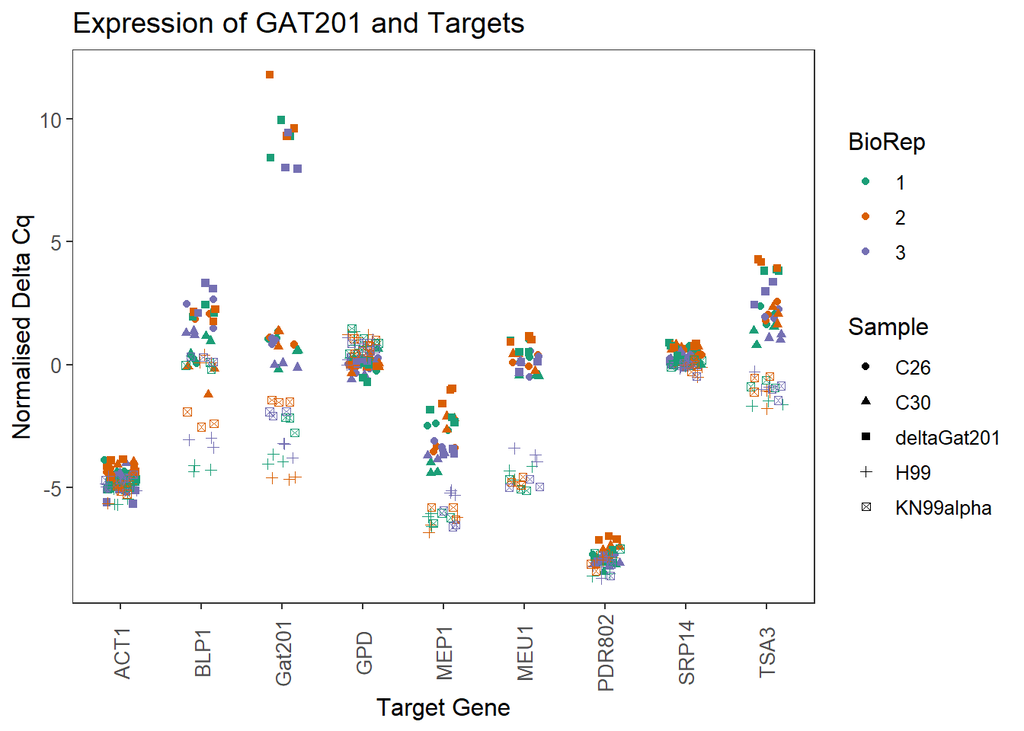

```r
ggplot(data = plates) +
  geom_point(aes(x = target_id, y = delta_cq, shape = Sample, colour = BioRep ),
    position = position_jitter(width = 0.2, height = 0)
  ) +

  labs(x = "Target Gene",
       y = "Normalised Delta Cq",
       title = "Expression of GAT201 and Targets") +
    theme(text = element_text(size = 12)) +
    theme(axis.text.x = element_text(size = 10))+
    theme(axis.text.y = element_text(size= 10))+
    scale_color_brewer(palette="Dark2")+
  theme(axis.text.x = element_text(angle = 90, vjust = 0.5))
```

## Save combined plots with all genes, target genes only and reference genes only

```r
ggsave("../Results/plates.png",
 ,width = 10,height=7)
```

## Calculate a summary value for each sample-target combination in combined plates

```r
plates_med <- plates %>%
  group_by(sample_id, Sample, target_id) %>%
  summarize(
    delta_cq  = median(delta_cq, na.rm = TRUE),
    rel_abund = median(rel_abund, na.rm = TRUE)
  )
```

### Filter plates_med for individual genes

```r
filter(plates_med, target_id == "Gat201")
```

```
## # A tibble: 15 × 5
## # Groups:   sample_id, Sample [15]
##    sample_id     Sample      target_id delta_cq rel_abund
##    <chr>         <chr>       <chr>        <dbl>     <dbl>
##  1 C26-1         C26         Gat201      1.07     0.476
##  2 C26-2         C26         Gat201      0.84     0.559
##  3 C26-3         C26         Gat201      0.990    0.503
##  4 C30-1         C30         Gat201      0.550    0.683
##  5 C30-2         C30         Gat201      1.36     0.390
##  6 C30-3         C30         Gat201     -0.0100   1.01
##  7 deltaGat201-1 deltaGat201 Gat201      9.3      0.00159
##  8 deltaGat201-2 deltaGat201 Gat201      9.62     0.00127
##  9 deltaGat201-3 deltaGat201 Gat201      8.03     0.00383
## 10 H99-1         H99         Gat201     -3.94    15.3
## 11 H99-2         H99         Gat201     -4.61    24.4
## 12 H99-3         H99         Gat201     -3.22     9.32
## 13 KN99alpha-1   KN99alpha   Gat201     -2.16     4.47
## 14 KN99alpha-2   KN99alpha   Gat201     -1.51     2.85
## 15 KN99alpha-3   KN99alpha   Gat201     -1.91     3.76
```

```r
filter(plates_med, target_id == "PDR802")
```

```
## # A tibble: 15 × 5
## # Groups:   sample_id, Sample [15]
##    sample_id     Sample      target_id delta_cq rel_abund
##    <chr>         <chr>       <chr>        <dbl>     <dbl>
##  1 C26-1         C26         PDR802       -7.74      214.
##  2 C26-2         C26         PDR802       -7.97      251.
##  3 C26-3         C26         PDR802       -8.08      271.
##  4 C30-1         C30         PDR802       -8.13      280.
##  5 C30-2         C30         PDR802       -7.42      171.
##  6 C30-3         C30         PDR802       -8.13      280.
##  7 deltaGat201-1 deltaGat201 PDR802       -7.85      231.
##  8 deltaGat201-2 deltaGat201 PDR802       -7.11      138.
##  9 deltaGat201-3 deltaGat201 PDR802       -7.9       239.
## 10 H99-1         H99         PDR802       -8.49      360.
## 11 H99-2         H99         PDR802       -7.84      229.
## 12 H99-3         H99         PDR802       -8.21      296.
## 13 KN99alpha-1   KN99alpha   PDR802       -7.67      204.
## 14 KN99alpha-2   KN99alpha   PDR802       -8.11      276.
## 15 KN99alpha-3   KN99alpha   PDR802       -8.11      276.
```

```r
filter(plates_med, target_id == "TSA3")
```

```
## # A tibble: 15 × 5
## # Groups:   sample_id, Sample [15]
##    sample_id     Sample      target_id delta_cq rel_abund
##    <chr>         <chr>       <chr>        <dbl>     <dbl>
##  1 C26-1         C26         TSA3         2.07     0.238
##  2 C26-2         C26         TSA3         2.04     0.243
##  3 C26-3         C26         TSA3         1.93     0.262
##  4 C30-1         C30         TSA3         1.39     0.382
##  5 C30-2         C30         TSA3         2.06     0.240
##  6 C30-3         C30         TSA3         1.09     0.470
##  7 deltaGat201-1 deltaGat201 TSA3         3.82     0.0708
##  8 deltaGat201-2 deltaGat201 TSA3         4.17     0.0556
##  9 deltaGat201-3 deltaGat201 TSA3         2.99     0.126
## 10 H99-1         H99         TSA3        -1.62     3.07
## 11 H99-2         H99         TSA3        -1.10     2.14
## 12 H99-3         H99         TSA3        -0.900    1.87
## 13 KN99alpha-1   KN99alpha   TSA3        -0.890    1.85
## 14 KN99alpha-2   KN99alpha   TSA3        -0.540    1.45
## 15 KN99alpha-3   KN99alpha   TSA3        -1        2
```

```r
filter(plates_med, target_id == "BLP1")
```

```
## # A tibble: 15 × 5
## # Groups:   sample_id, Sample [15]
##    sample_id     Sample      target_id delta_cq rel_abund
##    <chr>         <chr>       <chr>        <dbl>     <dbl>
##  1 C26-1         C26         BLP1        0.240      0.847
##  2 C26-2         C26         BLP1        2.07       0.238
##  3 C26-3         C26         BLP1        2.46       0.182
##  4 C30-1         C30         BLP1        0.970      0.511
##  5 C30-2         C30         BLP1       -0.170      1.13
##  6 C30-3         C30         BLP1        1.3        0.406
##  7 deltaGat201-1 deltaGat201 BLP1        2.12       0.230
##  8 deltaGat201-2 deltaGat201 BLP1        2.15       0.225
##  9 deltaGat201-3 deltaGat201 BLP1        3.10       0.117
## 10 H99-1         H99         BLP1       -4.28      19.4
## 11 H99-2         H99         BLP1        0.0900     0.940
## 12 H99-3         H99         BLP1       -3.06       8.34
## 13 KN99alpha-1   KN99alpha   BLP1       -0.0300     1.02
## 14 KN99alpha-2   KN99alpha   BLP1       -2.4        5.28
## 15 KN99alpha-3   KN99alpha   BLP1        0.300      0.812
```

```r
filter(plates_med, target_id == "MEU1")
```

```
## # A tibble: 15 × 5
## # Groups:   sample_id, Sample [15]
##    sample_id     Sample      target_id delta_cq rel_abund
##    <chr>         <chr>       <chr>        <dbl>     <dbl>
##  1 C26-1         C26         MEU1        0.310      0.807
##  2 C26-2         C26         MEU1        0.0900     0.940
##  3 C26-3         C26         MEU1        0.340      0.790
##  4 C30-1         C30         MEU1       -0.440      1.36
##  5 C30-2         C30         MEU1        0.430      0.742
##  6 C30-3         C30         MEU1        0.110      0.927
##  7 deltaGat201-1 deltaGat201 MEU1        0.510      0.702
##  8 deltaGat201-2 deltaGat201 MEU1        1.01       0.497
##  9 deltaGat201-3 deltaGat201 MEU1        0.100      0.933
## 10 H99-1         H99         MEU1       -4.31      19.8
## 11 H99-2         H99         MEU1       -4.75      26.9
## 12 H99-3         H99         MEU1       -3.68      12.8
## 13 KN99alpha-1   KN99alpha   MEU1       -5.07      33.6
## 14 KN99alpha-2   KN99alpha   MEU1       -4.79      27.7
## 15 KN99alpha-3   KN99alpha   MEU1       -4.96      31.1
```

```r
filter(plates_med, target_id == "MEP1")
```

```
## # A tibble: 15 × 5
## # Groups:   sample_id, Sample [15]
##    sample_id     Sample      target_id delta_cq rel_abund
##    <chr>         <chr>       <chr>        <dbl>     <dbl>
##  1 C26-1         C26         MEP1         -2.5       5.66
##  2 C26-2         C26         MEP1         -3.4      10.6
##  3 C26-3         C26         MEP1         -3.36     10.3
##  4 C30-1         C30         MEP1         -4.39     21.0
##  5 C30-2         C30         MEP1         -2.18      4.53
##  6 C30-3         C30         MEP1         -3.69     12.9
##  7 deltaGat201-1 deltaGat201 MEP1         -2.14      4.41
##  8 deltaGat201-2 deltaGat201 MEP1         -1.03      2.04
##  9 deltaGat201-3 deltaGat201 MEP1         -3.64     12.5
## 10 H99-1         H99         MEP1         -6.19     73.0
## 11 H99-2         H99         MEP1         -6.52     91.8
## 12 H99-3         H99         MEP1         -5.21     37.0
## 13 KN99alpha-1   KN99alpha   MEP1         -6.23     75.1
## 14 KN99alpha-2   KN99alpha   MEP1         -5.8      55.7
## 15 KN99alpha-3   KN99alpha   MEP1         -6.51     91.1
```

## Plot relative abundance for normalized data combined plates ref genes

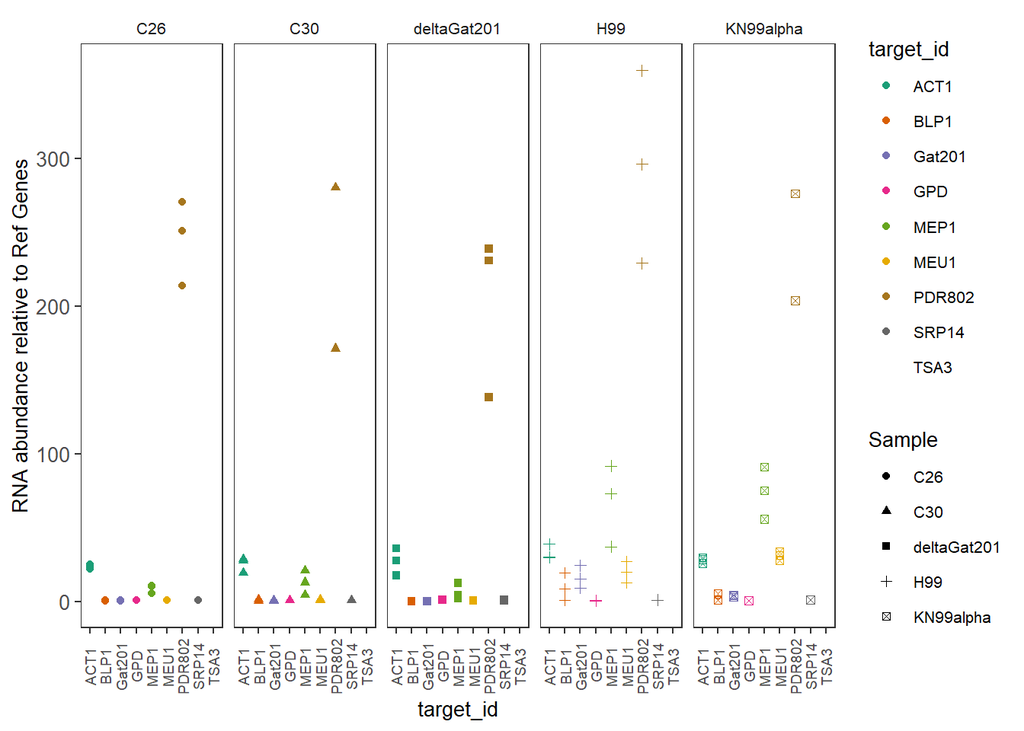

```r
ggplot(data = filter(plates_med, target_id != c("SRP14", "ACT1", "GPD"))) +
  geom_point(aes(x = target_id, y = rel_abund, shape = Sample, colour = target_id)) +
  labs(   y = "RNA abundance relative to Ref Genes" ) +
  facet_wrap(~Sample, ncol=5) +
 theme(text = element_text(size = 10)) +
    theme(axis.text.x = element_text(size = 10))+
    theme(axis.text.y = element_text(size= 10))+
    scale_color_brewer(palette="Dark2")+
  theme(axis.text.x = element_text(angle = 90, vjust = 0.5, size =7))
```

## Doubly normalized data: delta delta Cq combined plates

### Calculate delta delta cq against a chosen reference sample KN99-alpha (WT)

This is an estimate of log2 fold change. Combined plates Compare WT to other strains in the same growth conditions

```r
plates_deltanorm <- plates_med %>%
  calculate_deltadeltacq_bytargetid(ref_sample_ids = "KN99alpha-1")

plates_deltanorm_med <- plates_deltanorm %>%
    group_by(sample_id, Sample, target_id) %>%
  summarize(
    deltadelta_cq  = median(deltadelta_cq, na.rm = TRUE),
    fold_change    = median(fold_change,   na.rm = TRUE)
  )

plates_deltanorm
```

```
## # A tibble: 135 × 8
##    sample_id     Sample      target_id delta_cq rel_ab…¹ ref_d…² delta…³ fold_…⁴
##    <chr>         <chr>       <chr>        <dbl>    <dbl>   <dbl>   <dbl>   <dbl>
##  1 C26-1         C26         ACT1         -4.57     23.8   -4.82 -0.250    0.841
##  2 C26-2         C26         ACT1         -4.45     21.9   -4.82 -0.37     0.774
##  3 C26-3         C26         ACT1         -4.63     24.9   -4.82 -0.185    0.880
##  4 C30-1         C30         ACT1         -4.78     27.5   -4.82 -0.0400   0.973
##  5 C30-2         C30         ACT1         -4.25     19.2   -4.82 -0.57     0.674
##  6 C30-3         C30         ACT1         -4.85     28.8   -4.82  0.0300   1.02
##  7 deltaGat201-1 deltaGat201 ACT1         -4.80     27.8   -4.82 -0.0250   0.983
##  8 deltaGat201-2 deltaGat201 ACT1         -4.13     17.6   -4.82 -0.685    0.622
##  9 deltaGat201-3 deltaGat201 ACT1         -5.16     35.8   -4.82  0.340    1.27
## 10 H99-1         H99         ACT1         -5.27     38.9   -4.82  0.450    1.37
## # … with 125 more rows, and abbreviated variable names ¹rel_abund,
## #   ²ref_delta_cq, ³deltadelta_cq, ⁴fold_change
```

```r
plates_deltanorm_med
```

```
## # A tibble: 135 × 5
## # Groups:   sample_id, Sample [15]
##    sample_id Sample target_id deltadelta_cq fold_change
##    <chr>     <chr>  <chr>             <dbl>       <dbl>
##  1 C26-1     C26    ACT1            -0.250       0.841
##  2 C26-1     C26    BLP1            -0.270       0.829
##  3 C26-1     C26    Gat201          -3.23        0.107
##  4 C26-1     C26    GPD              0.865       1.82
##  5 C26-1     C26    MEP1            -3.73        0.0754
##  6 C26-1     C26    MEU1            -5.38        0.0240
##  7 C26-1     C26    PDR802           0.0700      1.05
##  8 C26-1     C26    SRP14           -0.595       0.662
##  9 C26-1     C26    TSA3            -2.96        0.129
## 10 C26-2     C26    ACT1            -0.37        0.774
## # … with 125 more rows
```

## Plot delta delta Cq (log2-fold change) for each target gene in combined plates

Here, delta delta Cq is positive when a target is more highly detected in the relevant sample, compared to reference samples.

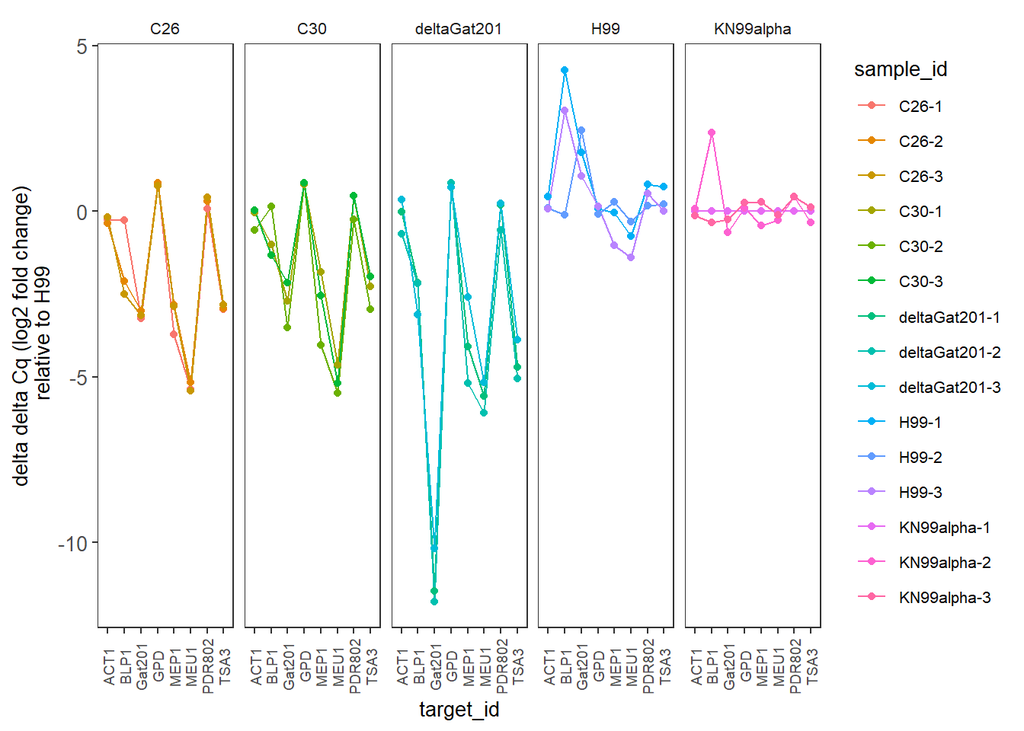

```r
ggplot(data = filter(plates_deltanorm_med, target_id != "SRP14") ) +
  geom_line(aes(x = target_id, y = deltadelta_cq, colour = sample_id, group = sample_id)) +
  geom_point(aes(x = target_id, y = deltadelta_cq,  colour = sample_id)) +
  labs(
    y = "delta delta Cq (log2 fold change)\n relative to H99"
  ) +
  facet_wrap(~Sample, ncol=5) +
 theme(text = element_text(size = 10)) +
    theme(axis.text.x = element_text(size = 10))+
    theme(axis.text.y = element_text(size= 10))+
      theme(axis.text.x = element_text(angle = 90, vjust = 0.5, size= 7))
```

```r
ggsave("../Results/ddcq_plates.png",
 width = 10,height=7)
```

## Plot fold change for each target gene combined plates

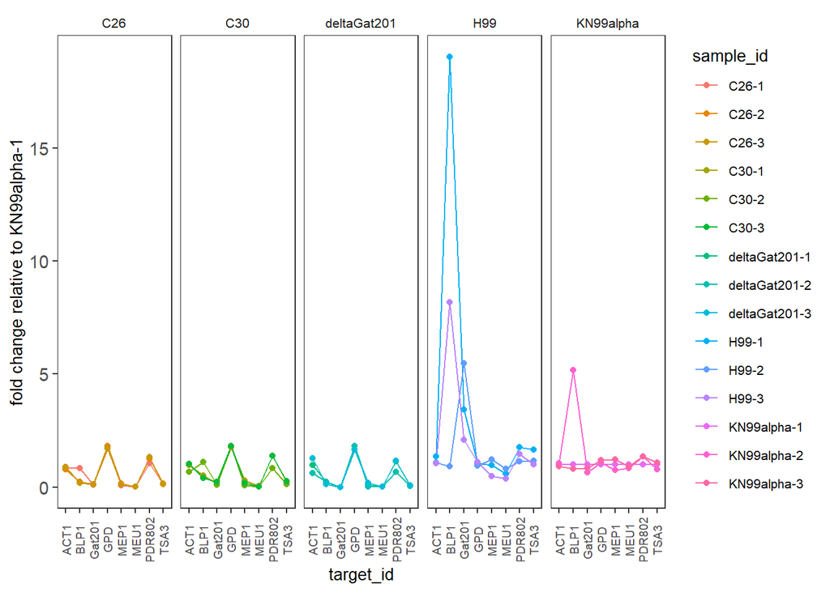

```r
ggplot(data = filter(plates_deltanorm_med, target_id != "SRP14") ) +
  geom_line(aes(x = target_id, y = fold_change, colour = sample_id, group = sample_id)) +
  geom_point(aes(x = target_id, y = fold_change, colour = sample_id)) +
  labs(
    y = "fold change relative to KN99alpha-1"
  ) +
  facet_wrap(~Sample,ncol=5) +
 theme(text = element_text(size = 10)) +
    theme(axis.text.x = element_text(size = 11))+
    theme(axis.text.y = element_text(size= 11))+
      theme(axis.text.x = element_text(angle = 90, vjust = 0.5, size= 7))
```

## Save fold change combined plates

```r
ggsave("../Results/fc_plates.png",
 width = 10,height=7)
```